# SI

Escola Secundária de Odivelas

Fundamentos de Sistemas Operativos

Curso Profissional de Multimédia

Rui Fartaria · 2026/2027

## O que é um sistema operativo?

Um sistema operativo é o software que permite ao **utilizador** e às **aplicações** utilizar os recursos do computador.

↓

**SISTEMA OPERATIVO**

Gere os recursos e coordena o funcionamento do sistema.

↓

**HARDWARE**

CPU · Memória · Armazenamento · Dispositivos

O sistema operativo funciona como **intermediário entre o software e o hardware**.

## Para que serve um sistema operativo?

O sistema operativo **gere os recursos do computador** e disponibiliza serviços às aplicações e ao utilizador.

**PROCESSADOR**

Distribui o tempo de CPU pelos programas em execução.

**MEMÓRIA**

Controla a utilização da RAM e da memória virtual.

**ARMAZENAMENTO**

Organiza os dados em ficheiros, diretórios e volumes.

**DISPOSITIVOS**

Coordena a comunicação com periféricos e outros componentes.

**FICHEIROS**

Permite criar, guardar, localizar, copiar e eliminar informação.

**UTILIZADORES E SEGURANÇA**

Controla contas, permissões e acesso aos recursos do sistema.

**O sistema operativo coordena tudo isto ao mesmo tempo.**

## Como comunicamos com o sistema operativo?

O sistema operativo disponibiliza diferentes formas de interação com o utilizador.

**INTERFACE GRÁFICA — GUI**

Janelas · Ícones · Menus · Botões

Permite interagir com o sistema através de elementos visuais, normalmente utilizando rato, teclado ou toque.

**Exemplos:** ambiente de trabalho do Windows, GNOME, KDE.

↔︎

**LINHA DE COMANDOS — CLI**

Comandos · Opções · Parâmetros

Permite controlar o sistema escrevendo instruções num terminal ou consola.

**Exemplos:** PowerShell, Command Prompt, Bash.

GUI e CLI são **formas diferentes de comunicar com o mesmo sistema operativo**.

## Exemplos de interface gráfica

[figure not shown]

Menu Iniciar · Barra de tarefas · Janelas

### Ubuntu

[figure not shown]

Dock · Barra superior · Janelas

Interfaces diferentes, mas a mesma função: **permitir ao utilizador interagir com o sistema operativo**.

## Exemplos de linha de comandos

### Windows

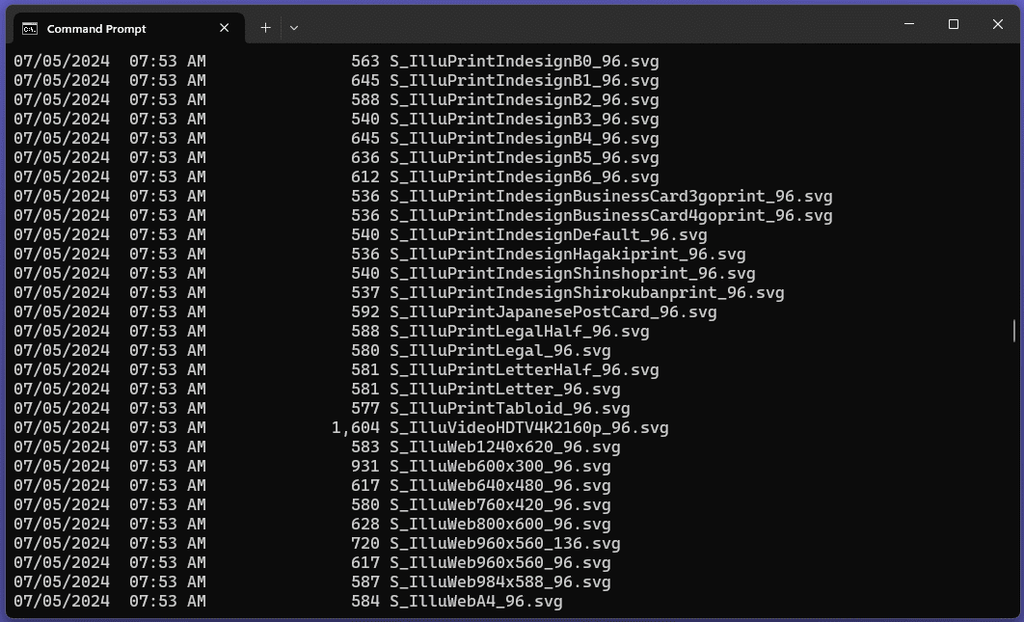

PowerShell / Terminal · Comandos · Parâmetros

### Linux

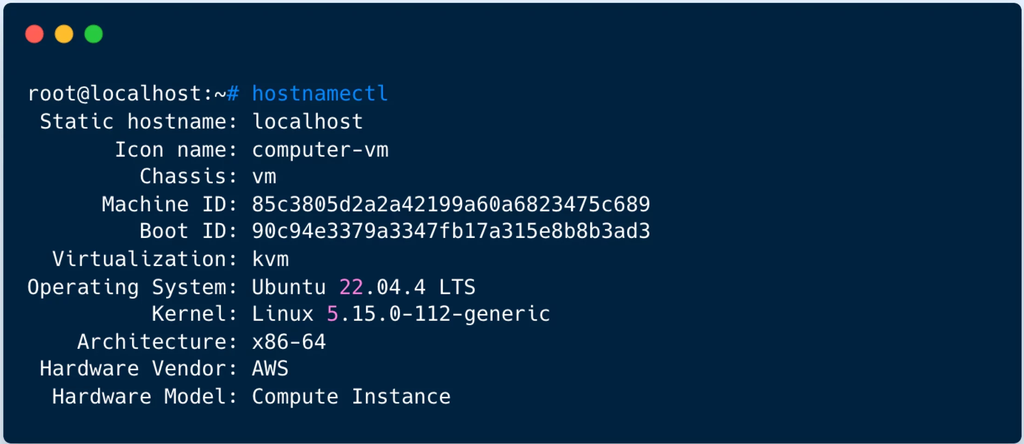

Terminal · Bash · Comandos

Na linha de comandos, comunicamos com o sistema operativo através de **instruções escritas**.

## O kernel

O **kernel** é a parte central do sistema operativo.

**UTILIZADOR E APLICAÇÕES**

Programas · Interface gráfica · Terminal

↓

**KERNEL**

Gere os recursos essenciais do sistema.

↓

**HARDWARE**

CPU · Memória · Armazenamento · Dispositivos

**PROCESSADOR**

Decide que processos utilizam a CPU e quando.

**MEMÓRIA**

Controla a utilização da memória pelos processos.

**DISPOSITIVOS**

Coordena a comunicação entre software e hardware.

**RECURSOS DO SISTEMA**

Controla o acesso aos recursos essenciais do computador.

As aplicações não controlam diretamente o hardware: comunicam com ele através do **sistema operativo e do kernel**.

## Programas e processos

Um **programa** é um conjunto de instruções armazenado no computador.  
Quando é executado, passa a existir como um **processo**.

**PROGRAMA**

Ficheiro armazenado

`chrome.exe` · `python` · `libreoffice`

→

**PROCESSO**

Programa em execução

Utiliza CPU · memória · outros recursos

**Multitarefa**

Browser

Editor

Música

Sistema

CPU

O sistema operativo gere vários processos e distribui os recursos disponíveis entre eles.

Um mesmo programa pode originar **vários processos**, e o sistema operativo decide como os recursos são utilizados.

## Gestão de memória

A **memória RAM** guarda temporariamente os dados e instruções de que os processos precisam enquanto estão em execução.

**RAM**

Browser

Editor

Sistema

Espaço disponível

↕

**MEMÓRIA VIRTUAL**

Espaço no armazenamento utilizado quando a RAM disponível não é suficiente.

**ALOCAÇÃO**

O sistema operativo atribui memória aos processos.

**ISOLAMENTO**

Cada processo deve usar apenas a memória que lhe foi atribuída.

**LIBERTAÇÃO**

Quando um processo termina, a memória pode voltar a ser utilizada.

**MEMÓRIA VIRTUAL**

Permite complementar a RAM recorrendo ao armazenamento.

A RAM é muito mais rápida do que o armazenamento, por isso a memória virtual é útil, mas **não substitui RAM suficiente**.

## Ficheiros e diretórios

O sistema operativo organiza a informação em **ficheiros**, agrupados em **diretórios**.

**VOLUME** Área de armazenamento

**PASTA** Documentos

**SUBPASTA** Trabalhos

**FICHEIRO** relatorio.pdf

**FICHEIROS**

Guardam informação: documentos, imagens, programas, configurações, etc.

**DIRETÓRIOS**

Permitem organizar ficheiros e outras pastas.

**ESTRUTURA HIERÁRQUICA**

Diretórios podem conter outros diretórios e ficheiros.

Um sistema de ficheiros permite **organizar e localizar a informação**.

## Caminhos e volumes

Um **caminho** indica a localização de um ficheiro ou diretório dentro de um sistema de ficheiros.

**VOLUME** Área de armazenamento disponibilizada pelo sistema operativo.

↓

**DIRETÓRIOS** Organizam a informação numa estrutura hierárquica.

↓

**FICHEIRO** Elemento final localizado através de um caminho.

**WINDOWS** `C:\Users\Rui\Documents\relatorio.pdf`

Usa normalmente uma letra para identificar o volume.

**LINUX** `/home/rui/Documents/relatorio.pdf`

Os caminhos partem de uma única raiz: `/`.

Sistemas diferentes podem representar os caminhos de forma diferente, mas o objetivo é o mesmo: **localizar recursos no sistema de ficheiros**.

## Dispositivos e controladores

O sistema operativo precisa de comunicar com muitos componentes de hardware diferentes.

**SISTEMA OPERATIVO** Windows · Linux

↓

**CONTROLADOR (DRIVER)** Traduz a comunicação entre o sistema operativo e o dispositivo.

↓

**DISPOSITIVO** Impressora · Placa gráfica · Rede · Áudio · Armazenamento

**IDENTIFICAÇÃO**

O sistema operativo deteta o hardware ligado ao computador.

**CONFIGURAÇÃO**

Define como o dispositivo deve funcionar e que recursos utiliza.

**CONTROLADORES**

Permitem ao sistema operativo comunicar corretamente com o hardware.

**DIAGNÓSTICO**

Ferramentas do sistema ajudam a identificar falhas e problemas de configuração.

Sem o controlador adequado, um dispositivo pode ser detetado mas **não funcionar corretamente**.

## Utilizadores e privilégios

Um sistema operativo permite criar diferentes **contas de utilizador** e controlar o acesso aos recursos do computador.

**ADMINISTRADOR / ROOT** Pode alterar configurações importantes, instalar software e gerir outros utilizadores.

↓

**UTILIZADOR NORMAL** Utiliza aplicações e ficheiros dentro das permissões que lhe foram atribuídas.

↓

**RECURSOS** Ficheiros · Pastas · Aplicações · Dispositivos · Configurações

**CONTAS**

Identificam cada utilizador no sistema.

**PERMISSÕES**

Definem que ações cada utilizador pode realizar.

**PRIVILÉGIOS**

Determinadas tarefas exigem permissões mais elevadas.

**SEGURANÇA**

Limitar o acesso reduz o risco de alterações indevidas no sistema.

Nem todos os utilizadores devem ter os mesmos privilégios: aplica-se o princípio de **dar apenas o acesso necessário**.

## Como arranca um computador?

Quando ligamos o computador, o sistema operativo ainda **não está em execução**. O arranque acontece em várias etapas.

**1 · FIRMWARE** Inicializa o hardware e verifica os componentes essenciais.

→

**2 · BOOTLOADER** Localiza e prepara o carregamento do sistema operativo.

→

**3 · KERNEL** É carregado para memória e começa a gerir os recursos.

→

**4 · SERVIÇOS** São iniciados os serviços essenciais do sistema.

→

**5 · SESSÃO** O utilizador pode autenticar-se e começar a trabalhar.

O arranque transforma um computador desligado num sistema pronto a executar aplicações.

## Da teoria à prática

Nas próximas aulas vamos observar estes conceitos diretamente em **Windows** e **Linux**, recorrendo a máquinas virtuais.

**INSTALAR** Preparar uma máquina virtual e instalar um sistema operativo.

**CONFIGURAR** Ajustar definições do sistema, dispositivos e ambiente de trabalho.

**OBSERVAR** Processos, memória, ficheiros, dispositivos e utilizadores.

**COMPARAR** Identificar semelhanças e diferenças entre Windows e Linux.

**ADMINISTRAR** Criar utilizadores, gerir privilégios e controlar recursos.

**DIAGNOSTICAR** Utilizar ferramentas do sistema para analisar problemas e configurações.

O objetivo não é apenas conhecer os conceitos, mas **saber observá-los e aplicá-los num sistema real**.

## Do botão ao kernel

O processo de arranque começa no firmware e termina com o **kernel em execução**.

WINDOWS

LINUX

FIRMWARE

UEFI / BIOS

UEFI / BIOS

DISPOSITIVO DE ARRANQUE

SSD / HDD · USB Drive

SSD / HDD · USB Drive

BOOTLOADER

Windows Boot Manager

GRUB

KERNEL

Windows NT kernel

Linux kernel

Até aqui, o objetivo é passar do **hardware ligado** para um **sistema operativo capaz de gerir recursos**.

## Do kernel ao sistema utilizável

Depois de carregado, o kernel começa a preparar os recursos necessários para que o sistema possa ser utilizado.

WINDOWS

LINUX

DRIVERS

NVIDIA / AMD / Intel · Realtek

`amdgpu` · `iwlwifi`

SISTEMA DE FICHEIROS

`C:` · NTFS

`/` · ext4

SERVIÇOS

Windows Update · Defender

NetworkManager · `systemd-journald`

LOGIN

Windows sign-in

GDM / login em consola

O sistema vai ficando operacional à medida que são carregados **controladores, sistemas de ficheiros e serviços**.

## Da sessão ao ambiente de trabalho

Depois da autenticação, o sistema cria a **sessão do utilizador** e prepara o ambiente de trabalho.

WINDOWS

LINUX / UBUNTU

SESSÃO

Perfil e configurações do utilizador

Perfil e configurações do utilizador

GUI / SHELL

Windows Explorer · PowerShell

GNOME Shell · Bash

PROGRAMAS DE ARRANQUE

OneDrive · Teams

Update Notifier · aplicações configuradas

SISTEMA PRONTO

Ambiente de trabalho disponível

Ambiente de trabalho disponível

**ARRANQUE DO SISTEMA** Firmware → Bootloader → Kernel → Drivers → Serviços

**ARRANQUE DA SESSÃO** Login → Sessão → GUI/Shell → Aplicações do utilizador

Esta sequência é uma **simplificação**: alguns componentes podem ser carregados em paralelo ou em momentos diferentes.

## O que deves reter

Ao longo desta apresentação vimos os principais elementos que permitem a um sistema operativo funcionar e gerir o computador.

**SISTEMA OPERATIVO** Gere os recursos do computador e fornece serviços às aplicações e ao utilizador.

**KERNEL** É a parte central do sistema operativo e gere os recursos essenciais.

**PROCESSOS E MEMÓRIA** Os programas em execução utilizam CPU e memória, geridas pelo sistema operativo.

**FICHEIROS** O sistema de ficheiros organiza a informação em volumes, diretórios e ficheiros.

O sistema operativo coordena **recursos, processos e informação**.

## O que deves reter

O sistema operativo também controla o acesso ao hardware, aos utilizadores e ao próprio processo de arranque.

**DISPOSITIVOS** Os drivers permitem ao sistema operativo comunicar com o hardware.

**UTILIZADORES** Contas, permissões e privilégios controlam o acesso aos recursos do sistema.

**ARRANQUE** Firmware → Bootloader → Kernel → Drivers → Serviços → Login → Sessão

Um sistema operativo coordena **hardware, software e utilizadores** para transformar o computador num sistema utilizável.

## Próxima etapa: instalar um sistema operativo

Agora que já conhecemos os principais conceitos, podemos passar à **instalação e configuração prática** de sistemas operativos.

**1 · ESCOLHER** Selecionar o sistema operativo a instalar.

→

**2 · VERIFICAR** Confirmar os requisitos de hardware.

→

**3 · PREPARAR** Obter a imagem ISO e preparar o meio de instalação.

→

**4 · CONFIGURAR** Criar e configurar a máquina virtual.

→

**5 · ARRANCAR** Selecionar o dispositivo de boot.

→

**6 · INSTALAR** Executar a instalação e configurar o sistema.

**WINDOWS** Instalação e configuração numa máquina virtual.

**LINUX** Instalação e configuração numa máquina virtual.

A partir daqui, passamos dos **conceitos** para a **instalação e configuração real de sistemas operativos**.